##### **Fig. C.34:** EOC SGP distributions for the HOSS and LOSS scores by norm group: Physical Science.

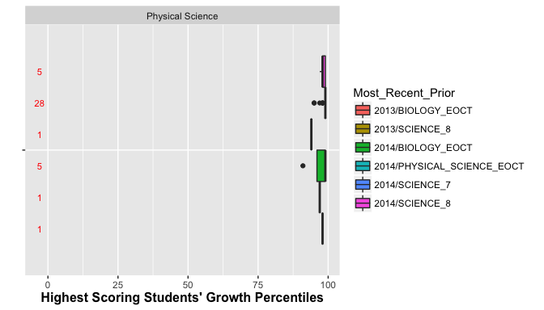

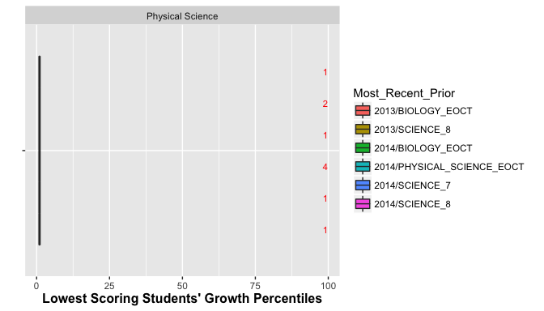

The plots for Coordinate Algebra are notable, particularly for the 2014 course repeater progression. This progression can also be seen in second-to-last plot of Figure C.24 above. Here we have isolated two students who scored the HOSS, 790. One student’s prior scale score was relatively low, although still quite high for the group overall at 480. This student’s SGP was estimated to be 99. The other student had a prior score of 600, which was perfect on the 2014 test (which begs the question of why this student was repeating the course to begin with!). This student’s SGP was estimated to be 1, which is probably an inaccurate assessment of this students growth since they have attained perfect scores two years in a row.

##### **Fig. C.35:** EOC SGP distributions for the HOSS and LOSS scores by norm group: Coordinate Algebra.

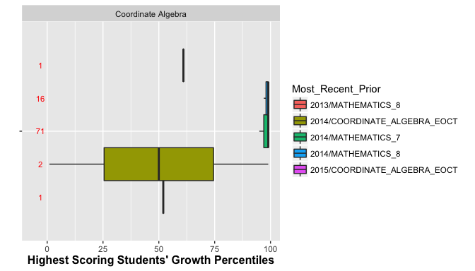

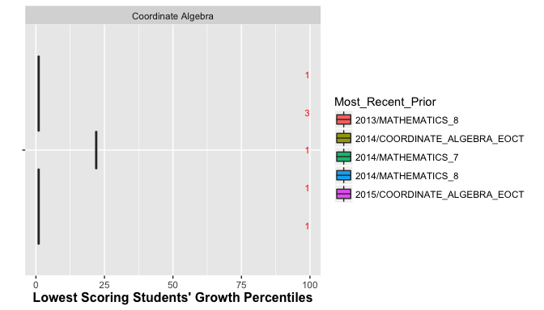

##### **Fig. C.36:** EOC SGP distributions for the HOSS and LOSS scores by norm group: Analytic Geometry.

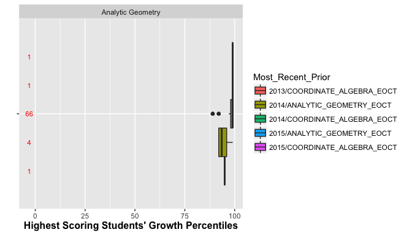

[figure not shown]

# 4 Discussion

Overall there is little evidence of floor or ceiling effects in the 2015 Georgia Milestones SGP analyses. Some scores for EOC test repeaters and skip year progressions suggest that a small number of minor problems may exist that could require changes.

When ceiling or floor effects are encountered, there are several ways in which they can be “corrected” manually or analytically. These include (but not limited to):

1. Convert all students scoring at the HOSS (LOSS) to 99 (1).
2. Run SGP analyses with more granular scores. For example, many tests that use Item Response Theory (IRT) to analyse test results provide scaled scores that enforce an artificial ceiling (floor), but also have more granular achievement scores available (IRT *θ* estimates).
3. Leave the results without a correction.